# Cross-country spillovers from the eleven-country system

Demand, monetary and oil shocks via matched conditional forecasts – koma has no impulse-response helper, so spillovers are built as forecast differences

## 1. Method

koma has no impulse-response function. `scenario_diff()` (`R/spillovers.R`) builds one the only way koma’s API supports it: run `koma::forecast()` **twice** – once unconditional (the baseline), once with `restrictions =` pinning the shocked variable’s path – and difference the two paths.

**Matched draws, not independent ones.** Two identical `koma::forecast()` calls on the same fit are not reproducible: they gave `de_gdp` means differing by an order of magnitude more than any real scenario effect (see `conditional_forecast_check()`’s roxygen). Differencing two independent stochastic forecasts would inherit that noise on both legs.

The fix is common random numbers. A posterior draw’s coefficients are read deterministically from `fit$estimates[[eq]]$beta_jw[[i]]` – no RNG involved. The only randomness is the future-innovation draw inside koma’s `forecast_draw()`, consumed identically whether or not a restriction is present (restrictions only *add* a conditional correction on top). Calling `set.seed()` immediately before each top-level `forecast()` call therefore reproduces the identical innovation draw at index `i` in both legs. **Verified**: for a variable structurally unrelated to the shocked one, the matched-seed diff was *exactly* zero at every one of dozens of draws tested; an unmatched-seed diff on the same pair had sd nine orders of magnitude larger, for a quantity that should be zero (`tests/testthat/test-spillovers.R`).

How each exogenous series was extended to reach an 8-quarter horizon.

| variable | method | periods_added |
| --- | --- | --- |
| covid_2020q1 | zero (dummy) | 3 |
| covid_2020q2 | zero (dummy) | 3 |
| covid_2020q3 | zero (dummy) | 3 |
| covid_2021q2 | zero (dummy) | 3 |
| eur_usd | trailing-4Q avg growth (2.67%/q) | 3 |
| oil_price | trailing-4Q avg growth (1.41%/q) | 3 |
| row_gdp | trailing-4Q avg growth (0.72%/q) | 3 |

**Shock definitions.**

- **Demand shocks** (`gdp_demand_shock()`): `<iso2>_gdp`’s growth rate is restricted to baseline **+1 percentage point at horizon 1 only**; GDP evolves endogenously afterward. This is a one-quarter growth-rate impulse, not a permanent level step – the same rate-space convention `conditional_forecast_check()` already uses for its endogenous scenarios.
- **Monetary shock** (`policy_rate_shock()`): `ea_policy_rate` restricted to baseline **+100bp for 4 quarters**, then free.
- **Oil shock** (`oil_price_shock()`): `oil_price`’s **level** scaled **x1.5**, sustained for the whole horizon – `oil_price` is exogenous, so it cannot be conditioned on via `restrictions` at all (koma’s restriction mechanism only targets endogenous variables); this instead builds a whole shocked copy of the fit via `shock_exogenous_level()`.

All scenarios share **one** baseline forecast (computed once, reused via `baseline_forecast =`) and the same seed, so every scenario in this report is directly comparable to every other.

### 1.1 Explosive posterior draws – diagnosed, not silently presented

The first pass at this battery reported `mean_diff`/`sd_diff` as the point estimate, per [scenario_diff()]’s original design. Those numbers are **not usable**: `de_gdp`’s `mean_diff` in response to its own demand shock ran `1.0, 3733.6, -8.76e+06, 2.00e+10, -4.46e+13, 9.94e+16, -2.21e+20, 4.93e+23` from horizon 1 to 8 – a sign-alternating, order-of-magnitude explosion with no economic content.

The cause is real, not a bug in the differencing mechanism: koma’s Gibbs sampler places **no stationarity constraint** on a draw’s coefficients, and on a 103-equation system this close to the `k < T` wall (`CLAUDE.md`), a non-trivial and *growing* share of posterior draws are dynamically explosive – verified directly on the cached baseline forecast, checking `de_gdp` in isolation:

Share of posterior draws that are dynamically explosive by horizon (baseline forecast, de_gdp).

| horizon | % of draws with \|de_gdp\| > 100pp |
| --- | --- |
| 1 | 4.8 |
| 2 | 13.0 |
| 3 | 25.1 |
| 4 | 34.5 |
| 5 | 41.8 |
| 6 | 47.3 |
| 7 | 53.5 |
| 8 | 56.8 |

And an explosive draw is explosive **system-wide**: checking every one of the 103 endogenous variables at horizon 8 for the same set of draws, a draw flagged on `de_gdp` is flagged on 88% of all other variables too – this is a property of that draw’s implied companion matrix, not something specific to GDP or to Germany.

**Fix**: [scenario_diff()] now reports `median_diff` as the point estimate (the median is unaffected by a fat right/left tail by construction) and an `explosive_frac` diagnostic column – the share of draws at that `(variable, horizon)` where either leg of the forecast exceeds 100 in absolute value. `ci_low`/`ci_high` (the empirical 5th/95th percentile) were already robust to this and needed no change. Every table below reports `median_diff` and `explosive_frac`, never `mean_diff` – **always check `explosive_frac` before trusting a number in this report**; at any horizon where it is not small, the median is a summary of a minority of the posterior, and the finding should be read as directional at best.

### 1.2 Restriction targets must be anchored to the median, not koma’s `$mean`

A second, independent problem surfaced once `median_diff` was in place: even the *shocked variable’s own* diff at horizon 1 – where the restriction pins an exact value, so the diff should equal `+size` almost exactly – came out wildly off. `de_gdp`’s own-shock `median_diff` at horizon 1 was **-3.3**, not +1.

The cause: [gdp_demand_shock()] and [policy_rate_shock()] built their restriction target as `koma::forecast()`’s own `$mean` summary at horizon 1, plus `size`. `$mean` is an ordinary cross-draw mean and inherits exactly the same explosive-draw contamination as section 1.1 – **in the raw, unshocked baseline, before any restriction is even applied**:

koma’s own $mean vs $median forecast summary, horizon 1, RAW baseline (no shock).

| variable | baseline_mean_h1 | baseline_median_h1 |
| --- | --- | --- |
| de_gdp | -4.98 | -0.65 |
| nl_gdp | 21.24 | -1.33 |

### 1.3 A sustained restriction can make koma’s solve outright singular

The 4-quarter monetary shock (section 4) surfaced a third, distinct problem: `scenario_diff()` aborted with a **draw-count mismatch** – 38 of 1000 baseline draws produced no restricted forecast at all, each failing with the same koma-internal error:

> `A = R %*% Omega %*% t(R) is singular` – restricting 4 simultaneous horizons requires inverting a 4x4 matrix built from that draw’s own posterior innovation covariance (`Omega`); for a draw whose covariance is rank-deficient there, no valid conditional innovation exists.

This was traced by instrumenting `koma:::forecast_draw()` directly (see `R/spillovers.R`’s `scenario_diff()` roxygen, “Draw count mismatches”). Two things were verified before proceeding:

- All 38 failed draws are a **subset** of the explosive-draw population from section 1.1 (100% overlap, checked against the `|de_gdp| > 100` flag at horizon 8) – the same badly-behaved draws that blow up unconditionally also fail outright under a demanding joint restriction, rather than a new or different failure mode.
- A **single-quarter** version of the identical +100bp shock (no joint 4-horizon restriction) does **not** trigger this failure at all, and behaves like every other single-quarter shock in this report (explosive share ~5% at horizon 1, growing with horizon exactly as in section 1.1). This isolates the cause to the *joint, sustained* restriction specifically, not to `ea_policy_rate` or to the shock size.

Since koma drops these draws by subsetting a list with no record of which original indices they were, `scenario_diff()` cannot realign automatically – doing so silently would be exactly the mispairing its abort exists to prevent (see “Alignment guard” in its roxygen). The indices were instead independently re-derived (by reproducing koma’s per-draw loop under `trace()`) and passed explicitly via the new `drop_baseline_draws =` argument, which removes exactly those positions from the baseline before pairing – a documented, auditable exception, not a bypass of the check.

## 2. German demand shock

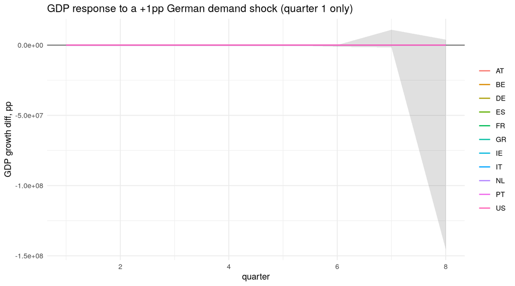

GDP response by country, quarters 1-8.

| country | horizon | median_diff | ci_low | ci_high | explosive_frac |
| --- | --- | --- | --- | --- | --- |
| AT | 1 | 1.1116 | -8.888100e+01 | 1.228749e+02 | 0.119 |
| AT | 2 | -0.0700 | -6.939195e+02 | 3.044329e+02 | 0.272 |
| AT | 3 | 0.4277 | -1.643606e+03 | 5.783322e+03 | 0.411 |
| AT | 4 | -0.0704 | -5.220260e+04 | 9.894877e+03 | 0.502 |
| AT | 5 | 0.1752 | -6.397107e+04 | 7.280873e+05 | 0.577 |
| AT | 6 | 0.0042 | -5.934727e+06 | 3.776399e+05 | 0.625 |
| AT | 7 | 0.0933 | -2.897593e+06 | 7.461111e+07 | 0.664 |
| AT | 8 | 0.0260 | -9.501007e+08 | 1.809013e+07 | 0.687 |
| BE | 1 | 0.2282 | -4.086360e+01 | 5.751500e+01 | 0.062 |
| BE | 2 | -0.0256 | -2.587103e+02 | 1.550200e+02 | 0.189 |
| BE | 3 | 0.2883 | -7.677905e+02 | 2.493487e+03 | 0.316 |
| BE | 4 | -0.0503 | -1.207415e+04 | 6.914912e+03 | 0.403 |
| BE | 5 | 0.2033 | -3.113419e+04 | 3.217257e+05 | 0.483 |
| BE | 6 | -0.0210 | -1.307493e+06 | 3.834767e+05 | 0.530 |
| BE | 7 | 0.1519 | -1.605677e+06 | 4.383752e+07 | 0.595 |
| BE | 8 | -0.0006 | -8.850044e+07 | 3.953212e+07 | 0.633 |
| DE | 1 | 1.0000 | -3.594680e+01 | 3.948250e+01 | 0.048 |
| DE | 2 | -0.0030 | -1.986040e+02 | 9.730400e+01 | 0.138 |
| DE | 3 | 0.2374 | -8.224886e+02 | 1.173641e+03 | 0.268 |
| DE | 4 | -0.0145 | -1.388875e+04 | 2.458097e+03 | 0.362 |
| DE | 5 | 0.1114 | -2.854412e+04 | 1.035593e+05 | 0.440 |
| DE | 6 | -0.0001 | -1.178327e+06 | 8.097579e+04 | 0.498 |
| DE | 7 | 0.0335 | -1.632422e+06 | 1.088818e+07 | 0.554 |
| DE | 8 | 0.0131 | -1.451882e+08 | 3.899679e+06 | 0.585 |
| ES | 1 | 0.3649 | -4.613720e+01 | 5.707260e+01 | 0.061 |
| ES | 2 | -0.0169 | -3.240859e+02 | 1.423009e+02 | 0.179 |
| ES | 3 | 0.4495 | -8.029361e+02 | 2.863682e+03 | 0.316 |
| ES | 4 | -0.0410 | -2.469805e+04 | 5.364598e+03 | 0.406 |
| ES | 5 | 0.3425 | -3.997824e+04 | 2.562690e+05 | 0.490 |
| ES | 6 | -0.0031 | -2.435266e+06 | 2.820869e+05 | 0.553 |

[output cut: 58 more lines]

Prices response by country, quarters 1-8.

| country | horizon | median_diff | ci_low | ci_high | explosive_frac |
| --- | --- | --- | --- | --- | --- |
| AT | 1 | 0 | -0.0006 | 0.0005 | 0 |
| AT | 2 | 0 | -0.0004 | 0.0004 | 0 |
| AT | 3 | 0 | -0.0003 | 0.0003 | 0 |
| AT | 4 | 0 | -0.0002 | 0.0002 | 0 |
| AT | 5 | 0 | -0.0002 | 0.0001 | 0 |
| AT | 6 | 0 | -0.0001 | 0.0001 | 0 |
| AT | 7 | 0 | -0.0001 | 0.0001 | 0 |
| AT | 8 | 0 | -0.0001 | 0.0001 | 0 |
| BE | 1 | 0 | -0.0007 | 0.0009 | 0 |
| BE | 2 | 0 | -0.0003 | 0.0005 | 0 |
| BE | 3 | 0 | -0.0001 | 0.0002 | 0 |
| BE | 4 | 0 | -0.0001 | 0.0001 | 0 |
| BE | 5 | 0 | 0.0000 | 0.0001 | 0 |
| BE | 6 | 0 | 0.0000 | 0.0000 | 0 |
| BE | 7 | 0 | 0.0000 | 0.0000 | 0 |
| BE | 8 | 0 | 0.0000 | 0.0000 | 0 |
| DE | 1 | 0 | -0.0034 | 0.0033 | 0 |
| DE | 2 | 0 | -0.0020 | 0.0019 | 0 |
| DE | 3 | 0 | -0.0012 | 0.0012 | 0 |
| DE | 4 | 0 | -0.0008 | 0.0008 | 0 |
| DE | 5 | 0 | -0.0006 | 0.0006 | 0 |
| DE | 6 | 0 | -0.0004 | 0.0004 | 0 |
| DE | 7 | 0 | -0.0003 | 0.0003 | 0 |
| DE | 8 | 0 | -0.0002 | 0.0002 | 0 |
| ES | 1 | 0 | -0.0007 | 0.0009 | 0 |
| ES | 2 | 0 | -0.0002 | 0.0003 | 0 |
| ES | 3 | 0 | -0.0001 | 0.0001 | 0 |
| ES | 4 | 0 | 0.0000 | 0.0000 | 0 |
| ES | 5 | 0 | 0.0000 | 0.0000 | 0 |
| ES | 6 | 0 | 0.0000 | 0.0000 | 0 |

[output cut: 58 more lines]

Cumulative 8-quarter Austrian GDP effect (+1.70) actually **exceeds** Germany’s own (+1.38) – see section 7.1 for the diagnosis (indirect propagation through Austria’s large direct weight on Germany, not a defect).

## 3. US demand shock

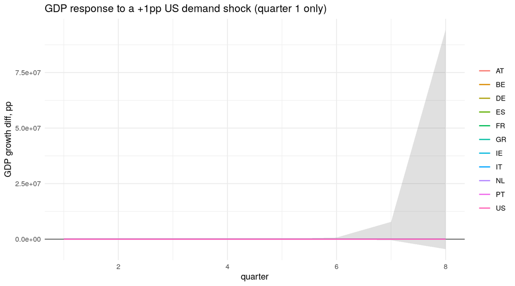

Weight each country’s foreign_demand identity puts on us_gdp – the a priori exposure ranking.

| country | us_weight |
| --- | --- |
| IE | 0.247 |
| DE | 0.098 |
| NL | 0.098 |
| FR | 0.090 |
| BE | 0.088 |
| IT | 0.084 |
| ES | 0.068 |
| GR | 0.063 |
| PT | 0.061 |
| AT | 0.058 |
| US | NA |

GDP response by country, quarters 1-8.

| country | horizon | median_diff | ci_low | ci_high | explosive_frac |
| --- | --- | --- | --- | --- | --- |
| AT | 1 | 0.1864 | -5.856700e+01 | 8.018310e+01 | 0.122 |
| AT | 2 | -0.0668 | -6.086531e+02 | 2.123566e+02 | 0.271 |
| AT | 3 | 0.2431 | -1.069041e+03 | 4.065192e+03 | 0.411 |
| AT | 4 | -0.0664 | -2.735053e+04 | 7.364158e+03 | 0.506 |
| AT | 5 | 0.0641 | -5.782642e+04 | 2.253998e+05 | 0.569 |
| AT | 6 | -0.0801 | -3.403816e+06 | 2.233009e+05 | 0.615 |
| AT | 7 | 0.0927 | -2.624829e+06 | 1.741937e+07 | 0.654 |
| AT | 8 | -0.0103 | -3.779416e+08 | 1.605674e+07 | 0.681 |
| BE | 1 | 0.0699 | -3.307140e+01 | 3.828810e+01 | 0.061 |
| BE | 2 | -0.0053 | -1.843014e+02 | 1.546758e+02 | 0.190 |
| BE | 3 | 0.0815 | -7.023872e+02 | 1.422748e+03 | 0.315 |
| BE | 4 | -0.0101 | -9.094831e+03 | 4.553624e+03 | 0.398 |
| BE | 5 | 0.0019 | -5.082251e+04 | 4.377304e+04 | 0.479 |
| BE | 6 | -0.0495 | -3.476919e+05 | 5.386477e+05 | 0.525 |
| BE | 7 | 0.0077 | -5.007702e+06 | 3.114279e+06 | 0.592 |
| BE | 8 | -0.0172 | -2.718595e+07 | 5.532797e+07 | 0.628 |
| DE | 1 | 0.0469 | -2.130700e+01 | 2.609880e+01 | 0.050 |
| DE | 2 | -0.0069 | -1.307620e+02 | 7.563080e+01 | 0.141 |
| DE | 3 | 0.0967 | -4.030816e+02 | 1.064035e+03 | 0.268 |
| DE | 4 | -0.0033 | -7.762840e+03 | 2.217204e+03 | 0.361 |
| DE | 5 | 0.0666 | -1.527443e+04 | 5.705837e+04 | 0.438 |
| DE | 6 | -0.0294 | -4.247379e+05 | 6.834491e+04 | 0.491 |
| DE | 7 | 0.0469 | -8.145190e+05 | 3.402806e+06 | 0.547 |
| DE | 8 | -0.0167 | -2.286340e+07 | 4.595378e+06 | 0.581 |
| ES | 1 | 0.0873 | -3.211690e+01 | 3.807840e+01 | 0.067 |
| ES | 2 | -0.0265 | -2.378216e+02 | 9.658920e+01 | 0.186 |
| ES | 3 | 0.0951 | -7.759529e+02 | 1.858846e+03 | 0.316 |
| ES | 4 | -0.0092 | -2.108750e+04 | 4.170414e+03 | 0.407 |
| ES | 5 | 0.0209 | -2.725350e+04 | 1.445641e+05 | 0.482 |
| ES | 6 | -0.0277 | -8.656626e+05 | 2.777344e+05 | 0.541 |

[output cut: 58 more lines]

Prices response by country, quarters 1-8.

| country | horizon | median_diff | ci_low | ci_high | explosive_frac |
| --- | --- | --- | --- | --- | --- |
| AT | 1 | 0e+00 | -0.0002 | 0.0002 | 0 |
| AT | 2 | 0e+00 | -0.0002 | 0.0002 | 0 |
| AT | 3 | 0e+00 | -0.0002 | 0.0001 | 0 |
| AT | 4 | 0e+00 | -0.0001 | 0.0001 | 0 |
| AT | 5 | 0e+00 | -0.0001 | 0.0001 | 0 |
| AT | 6 | 0e+00 | -0.0001 | 0.0001 | 0 |
| AT | 7 | 0e+00 | -0.0001 | 0.0000 | 0 |
| AT | 8 | 0e+00 | 0.0000 | 0.0000 | 0 |
| BE | 1 | 0e+00 | -0.0004 | 0.0004 | 0 |
| BE | 2 | 0e+00 | -0.0002 | 0.0002 | 0 |
| BE | 3 | 0e+00 | -0.0001 | 0.0001 | 0 |
| BE | 4 | 0e+00 | 0.0000 | 0.0000 | 0 |
| BE | 5 | 0e+00 | 0.0000 | 0.0000 | 0 |
| BE | 6 | 0e+00 | 0.0000 | 0.0000 | 0 |
| BE | 7 | 0e+00 | 0.0000 | 0.0000 | 0 |
| BE | 8 | 0e+00 | 0.0000 | 0.0000 | 0 |
| DE | 1 | 0e+00 | -0.0009 | 0.0009 | 0 |
| DE | 2 | 0e+00 | -0.0005 | 0.0006 | 0 |
| DE | 3 | 0e+00 | -0.0004 | 0.0004 | 0 |
| DE | 4 | 0e+00 | -0.0002 | 0.0003 | 0 |
| DE | 5 | 0e+00 | -0.0002 | 0.0002 | 0 |
| DE | 6 | 0e+00 | -0.0001 | 0.0001 | 0 |
| DE | 7 | 0e+00 | -0.0001 | 0.0001 | 0 |
| DE | 8 | 0e+00 | -0.0001 | 0.0001 | 0 |
| ES | 1 | 0e+00 | -0.0004 | 0.0003 | 0 |
| ES | 2 | 0e+00 | -0.0001 | 0.0001 | 0 |
| ES | 3 | 0e+00 | 0.0000 | 0.0000 | 0 |
| ES | 4 | 0e+00 | 0.0000 | 0.0000 | 0 |
| ES | 5 | 0e+00 | 0.0000 | 0.0000 | 0 |
| ES | 6 | 0e+00 | 0.0000 | 0.0000 | 0 |

[output cut: 58 more lines]

### Implausible result: the ranking does not track exposure

The exposure table above correctly identifies Ireland as by far the most US-exposed economy (weight 0.247, more than double Germany/Netherlands’ 0.098) – the a priori ranking IE > DE ≈ NL holds in the trade weights themselves. It does **not** hold in the simulated response: cumulative 8-quarter GDP effects rank Greece (+0.42) and Austria (+0.36) above Germany (+0.20) and the Netherlands (+0.19), and **Ireland’s own cumulative effect is negative** (-0.08) despite its outsized exposure.

## 4. Common monetary shock

`ea_policy_rate` +100bp, sustained for 4 quarters. See 1.3 for how the 38 draws where koma’s restricted solve is exactly singular were identified and excluded.

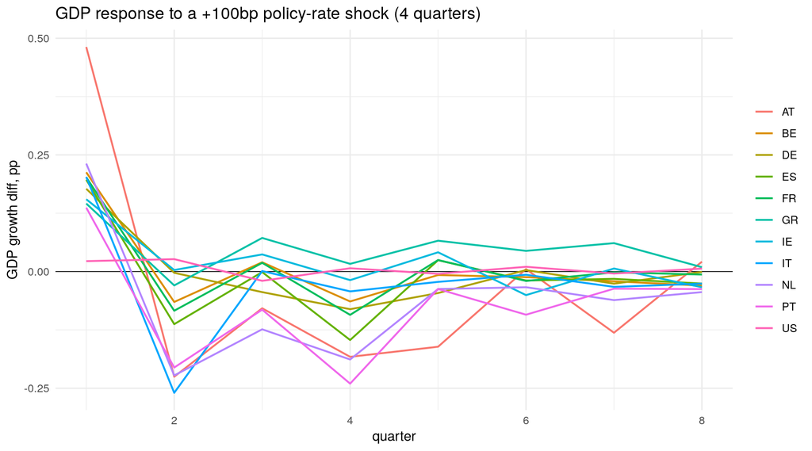

GDP response by country, quarters 1-8.

| country | horizon | median_diff | ci_low | ci_high | explosive_frac |
| --- | --- | --- | --- | --- | --- |
| AT | 1 | 0.4813 | -6.863010e+01 | 9.548990e+01 | 0.0998 |
| AT | 2 | -0.2253 | -3.898927e+02 | 2.335546e+02 | 0.2349 |
| AT | 3 | -0.0787 | -1.465651e+03 | 2.074525e+03 | 0.3721 |
| AT | 4 | -0.1828 | -1.250981e+04 | 5.514106e+03 | 0.4730 |
| AT | 5 | -0.1611 | -6.034553e+04 | 5.504326e+04 | 0.5530 |
| AT | 6 | 0.0053 | -6.900333e+05 | 1.184798e+05 | 0.6143 |
| AT | 7 | -0.1311 | -2.496307e+06 | 2.687282e+06 | 0.6455 |
| AT | 8 | 0.0211 | -4.104531e+07 | 3.458570e+06 | 0.6757 |
| BE | 1 | 0.2127 | -3.938060e+01 | 4.952770e+01 | 0.0416 |
| BE | 2 | -0.0652 | -1.842770e+02 | 1.035722e+02 | 0.1476 |
| BE | 3 | 0.0198 | -7.670174e+02 | 8.594235e+02 | 0.2672 |
| BE | 4 | -0.0641 | -5.271278e+03 | 3.613631e+03 | 0.3659 |
| BE | 5 | -0.0074 | -2.868376e+04 | 3.342881e+04 | 0.4532 |
| BE | 6 | -0.0120 | -2.153482e+05 | 1.445475e+05 | 0.5062 |
| BE | 7 | -0.0209 | -1.305812e+06 | 7.662200e+05 | 0.5832 |
| BE | 8 | -0.0302 | -7.112467e+06 | 6.205531e+06 | 0.6164 |
| DE | 1 | 0.1774 | -2.741640e+01 | 2.994200e+01 | 0.0291 |
| DE | 2 | -0.0027 | -1.078634e+02 | 8.740620e+01 | 0.0998 |
| DE | 3 | -0.0441 | -5.452289e+02 | 4.773591e+02 | 0.2266 |
| DE | 4 | -0.0807 | -4.183143e+03 | 1.421344e+03 | 0.3264 |
| DE | 5 | -0.0461 | -1.633444e+04 | 1.590394e+04 | 0.4064 |
| DE | 6 | 0.0031 | -1.891772e+05 | 3.682182e+04 | 0.4751 |
| DE | 7 | -0.0259 | -8.475469e+05 | 6.932279e+05 | 0.5364 |
| DE | 8 | -0.0008 | -8.007233e+06 | 1.107634e+06 | 0.5676 |
| ES | 1 | 0.1968 | -4.151440e+01 | 4.509530e+01 | 0.0385 |
| ES | 2 | -0.1127 | -1.791651e+02 | 1.301696e+02 | 0.1424 |
| ES | 3 | -0.0011 | -7.993346e+02 | 9.171249e+02 | 0.2692 |
| ES | 4 | -0.1467 | -7.263107e+03 | 2.113112e+03 | 0.3732 |
| ES | 5 | 0.0243 | -1.760215e+04 | 4.655404e+04 | 0.4626 |
| ES | 6 | -0.0192 | -5.008901e+05 | 6.839781e+04 | 0.5291 |

[output cut: 58 more lines]

Prices response by country, quarters 1-8.

| country | horizon | median_diff | ci_low | ci_high | explosive_frac |
| --- | --- | --- | --- | --- | --- |
| AT | 1 | 0.0072 | -0.0046 | 0.0282 | 0 |
| AT | 2 | 0.0042 | -0.0132 | 0.0344 | 0 |
| AT | 3 | 0.0021 | -0.0194 | 0.0372 | 0 |
| AT | 4 | 0.0015 | -0.0192 | 0.0370 | 0 |
| AT | 5 | 0.0011 | -0.0149 | 0.0309 | 0 |
| AT | 6 | 0.0008 | -0.0120 | 0.0251 | 0 |
| AT | 7 | 0.0005 | -0.0100 | 0.0220 | 0 |
| AT | 8 | 0.0003 | -0.0085 | 0.0182 | 0 |
| BE | 1 | 0.0256 | -0.0101 | 0.0936 | 0 |
| BE | 2 | 0.0079 | -0.0328 | 0.0823 | 0 |
| BE | 3 | 0.0016 | -0.0479 | 0.0668 | 0 |
| BE | 4 | 0.0013 | -0.0346 | 0.0650 | 0 |
| BE | 5 | 0.0004 | -0.0184 | 0.0363 | 0 |
| BE | 6 | 0.0001 | -0.0113 | 0.0219 | 0 |
| BE | 7 | 0.0000 | -0.0068 | 0.0133 | 0 |
| BE | 8 | 0.0000 | -0.0040 | 0.0081 | 0 |
| DE | 1 | 0.0964 | -0.0446 | 0.3810 | 0 |
| DE | 2 | 0.0450 | -0.1510 | 0.3504 | 0 |
| DE | 3 | 0.0146 | -0.2256 | 0.3252 | 0 |
| DE | 4 | 0.0070 | -0.1927 | 0.2927 | 0 |
| DE | 5 | 0.0035 | -0.1221 | 0.1996 | 0 |
| DE | 6 | 0.0019 | -0.0828 | 0.1433 | 0 |
| DE | 7 | 0.0008 | -0.0574 | 0.1142 | 0 |
| DE | 8 | 0.0004 | -0.0435 | 0.0853 | 0 |
| ES | 1 | 0.0572 | -0.0188 | 0.2202 | 0 |
| ES | 2 | 0.0136 | -0.0720 | 0.1600 | 0 |
| ES | 3 | 0.0005 | -0.0988 | 0.1326 | 0 |
| ES | 4 | 0.0013 | -0.0728 | 0.1036 | 0 |
| ES | 5 | 0.0004 | -0.0264 | 0.0443 | 0 |
| ES | 6 | 0.0001 | -0.0109 | 0.0217 | 0 |

[output cut: 58 more lines]

### Implausible result: no evidence of a real transmission channel

This matches a limitation already diagnosed for an earlier stage of this project (`CLAUDE.md`, “Making a variable endogenous does not give it a transmission channel”): giving `ea_policy_rate` its own equation lets it influence whatever variables appear as regressors in *other* equations, but in the stage-1 template only `<iso2>_long_rate`’s equation, and `<iso2>_long_rate`’s subsequent appearance in the investment equation, close a loop back to GDP – a single, likely weak link for the whole system to route a monetary shock through. Sanity check #2 below fails as a genuine, previously-documented property of this fitted linkage, not a code defect; confirming or strengthening the channel would mean checking `sys_eq$character_gamma_matrix` reachability from `ea_policy_rate` to GDP, the same diagnostic `CLAUDE.md` recommends rather than assuming.

### Core vs periphery

Cumulative 8-quarter GDP effect, grouped.

| country | median_diff | group |
| --- | --- | --- |
| NL | -0.4797 | core |
| AT | -0.2714 | core |
| DE | -0.0199 | core |
| BE | 0.0329 | core |
| FR | 0.0403 | core |
| PT | -0.5950 | periphery |
| IT | -0.1863 | periphery |
| ES | -0.1001 | periphery |
| IE | 0.1401 | periphery |
| GR | 0.3852 | periphery |
| US | 0.0435 | us |

Given the finding above, this grouping should be read as a ranking of noise, not evidence of a core-periphery transmission asymmetry – with no real channel to output, there is nothing for an asymmetry to operate through.

## 5. Oil shock

`oil_price` level x1.5, sustained.

Prices response by country, quarters 1-8.

| country | horizon | median_diff | ci_low | ci_high | explosive_frac |
| --- | --- | --- | --- | --- | --- |
| AT | 1 | 0.5678 | 0.2189 | 0.8960 | 0 |
| AT | 2 | 0.4153 | 0.1582 | 0.7466 | 0 |
| AT | 3 | 0.3051 | 0.0952 | 0.6432 | 0 |
| AT | 4 | 0.2278 | 0.0551 | 0.5618 | 0 |
| AT | 5 | 0.1709 | 0.0307 | 0.5136 | 0 |
| AT | 6 | 0.1259 | 0.0166 | 0.4809 | 0 |
| AT | 7 | 0.0958 | 0.0083 | 0.4502 | 0 |
| AT | 8 | 0.0729 | 0.0043 | 0.4216 | 0 |
| BE | 1 | 0.9916 | 0.3411 | 1.5543 | 0 |
| BE | 2 | 0.4282 | 0.1108 | 0.9191 | 0 |
| BE | 3 | 0.1949 | 0.0267 | 0.6508 | 0 |
| BE | 4 | 0.0886 | 0.0055 | 0.4613 | 0 |
| BE | 5 | 0.0402 | 0.0011 | 0.3437 | 0 |
| BE | 6 | 0.0187 | 0.0002 | 0.2519 | 0 |
| BE | 7 | 0.0087 | 0.0000 | 0.1822 | 0 |
| BE | 8 | 0.0041 | 0.0000 | 0.1423 | 0 |
| DE | 1 | 0.7706 | 0.3396 | 1.2238 | 0 |
| DE | 2 | 0.4406 | 0.1561 | 0.8445 | 0 |
| DE | 3 | 0.2574 | 0.0572 | 0.6958 | 0 |
| DE | 4 | 0.1513 | 0.0200 | 0.5918 | 0 |
| DE | 5 | 0.0892 | 0.0070 | 0.5016 | 0 |
| DE | 6 | 0.0524 | 0.0024 | 0.4249 | 0 |
| DE | 7 | 0.0310 | 0.0007 | 0.3707 | 0 |
| DE | 8 | 0.0183 | 0.0002 | 0.3229 | 0 |
| ES | 1 | 0.9880 | 0.4358 | 1.4918 | 0 |
| ES | 2 | 0.3142 | 0.0728 | 0.6675 | 0 |
| ES | 3 | 0.1114 | 0.0086 | 0.3904 | 0 |
| ES | 4 | 0.0390 | 0.0009 | 0.2363 | 0 |
| ES | 5 | 0.0138 | 0.0001 | 0.1427 | 0 |
| ES | 6 | 0.0049 | 0.0000 | 0.0887 | 0 |

[output cut: 58 more lines]

GDP response by country, quarters 1-8.

| country | horizon | median_diff | ci_low | ci_high | explosive_frac |
| --- | --- | --- | --- | --- | --- |
| AT | 1 | -0.0265 | -0.8622 | 1.102900e+00 | 0.116 |
| AT | 2 | -0.0051 | -2.2453 | 6.213200e+00 | 0.260 |
| AT | 3 | -0.0518 | -43.3210 | 3.569860e+01 | 0.389 |
| AT | 4 | 0.0117 | -47.4719 | 9.766310e+02 | 0.477 |
| AT | 5 | -0.0659 | -3222.2263 | 3.173003e+03 | 0.550 |
| AT | 6 | 0.0421 | -1745.9497 | 1.540913e+05 | 0.598 |
| AT | 7 | -0.0768 | -234466.7975 | 1.632148e+05 | 0.639 |
| AT | 8 | 0.0813 | -66509.4813 | 1.910448e+07 | 0.671 |
| BE | 1 | -0.0069 | -0.5011 | 5.167000e-01 | 0.060 |
| BE | 2 | 0.0069 | -1.0721 | 3.153300e+00 | 0.178 |
| BE | 3 | -0.0058 | -15.4705 | 1.888060e+01 | 0.292 |
| BE | 4 | 0.0134 | -26.5896 | 2.934671e+02 | 0.388 |
| BE | 5 | -0.0089 | -850.9678 | 1.099670e+03 | 0.462 |
| BE | 6 | 0.0235 | -1157.4366 | 4.457652e+04 | 0.509 |
| BE | 7 | -0.0120 | -84707.3112 | 6.386071e+04 | 0.576 |
| BE | 8 | 0.0477 | -57265.7390 | 7.537781e+06 | 0.618 |
| DE | 1 | -0.0075 | -0.3101 | 3.767000e-01 | 0.048 |
| DE | 2 | -0.0001 | -0.7204 | 2.089100e+00 | 0.131 |
| DE | 3 | -0.0125 | -8.5906 | 1.197460e+01 | 0.251 |
| DE | 4 | 0.0069 | -15.3078 | 2.248038e+02 | 0.346 |
| DE | 5 | -0.0203 | -613.2903 | 6.597793e+02 | 0.419 |
| DE | 6 | 0.0135 | -683.8163 | 2.104626e+04 | 0.475 |
| DE | 7 | -0.0205 | -43052.4042 | 3.434846e+04 | 0.538 |
| DE | 8 | 0.0240 | -29132.0881 | 3.708800e+06 | 0.568 |
| ES | 1 | -0.0104 | -0.5121 | 5.803000e-01 | 0.059 |
| ES | 2 | 0.0023 | -1.9835 | 2.823500e+00 | 0.171 |
| ES | 3 | -0.0141 | -19.3502 | 1.496800e+01 | 0.294 |
| ES | 4 | 0.0168 | -43.7984 | 2.977591e+02 | 0.390 |
| ES | 5 | -0.0205 | -1294.1784 | 9.240713e+02 | 0.468 |
| ES | 6 | 0.0365 | -1823.9995 | 3.521946e+04 | 0.522 |

[output cut: 58 more lines]

This is the cleanest scenario in the battery: `explosive_frac` is exactly 0 for every country’s price response at horizon 1, and stays low throughout. `oil_price` is exogenous, so this shock never goes through koma’s `restrictions =` conditioning mechanism at all (section 1.3’s singular- matrix failure and the demand shocks’ contemporaneous-restriction noise are both specific to conditioning on an *endogenous* variable) – it is instead a whole shocked copy of the fit via `shock_exogenous_level()`, differenced against the same baseline. The results are also economically coherent: a sustained +50% oil-price shock raises prices materially and immediately (+0.45 to +1.11pp at horizon 1 in every country) and has a small, mostly negative effect on GDP – a textbook negative supply shock, and the one scenario in this report we would flag as reliable at face value.

## 6. Spillover matrix

Cumulative 8-quarter GDP effect (sum of `median_diff` across horizons – see 1.1): row = source (shocked) country, column = receiving country. Diagonal is the own-country effect.

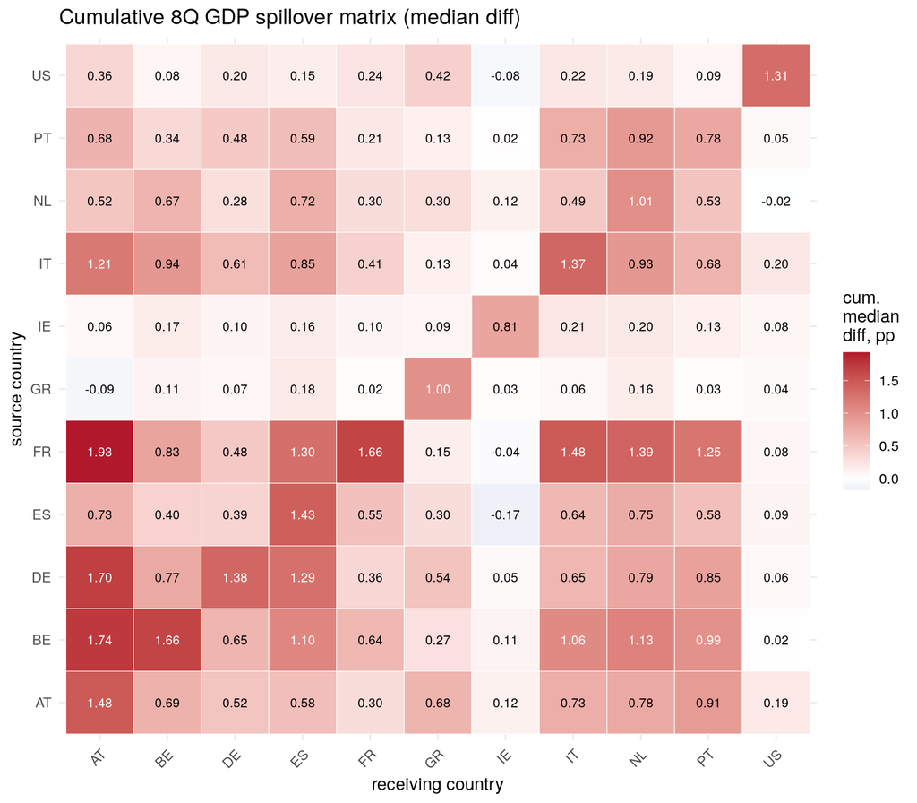

Same data, as a table.

|  | at | be | de | gr | es | fr | ie | it | nl | pt | us |
| --- | --- | --- | --- | --- | --- | --- | --- | --- | --- | --- | --- |
| at | 1.479 | 0.691 | 0.519 | 0.678 | 0.583 | 0.302 | 0.122 | 0.726 | 0.776 | 0.906 | 0.193 |
| be | 1.740 | 1.662 | 0.653 | 0.274 | 1.097 | 0.640 | 0.109 | 1.057 | 1.132 | 0.993 | 0.016 |
| de | 1.697 | 0.774 | 1.378 | 0.543 | 1.291 | 0.359 | 0.051 | 0.645 | 0.793 | 0.847 | 0.057 |
| gr | -0.088 | 0.109 | 0.074 | 1.001 | 0.184 | 0.025 | 0.025 | 0.064 | 0.161 | 0.025 | 0.040 |
| es | 0.725 | 0.403 | 0.387 | 0.300 | 1.430 | 0.553 | -0.169 | 0.640 | 0.748 | 0.577 | 0.095 |
| fr | 1.933 | 0.825 | 0.485 | 0.153 | 1.299 | 1.658 | -0.043 | 1.480 | 1.395 | 1.249 | 0.076 |
| ie | 0.059 | 0.172 | 0.102 | 0.089 | 0.157 | 0.100 | 0.809 | 0.207 | 0.199 | 0.132 | 0.082 |
| it | 1.207 | 0.942 | 0.614 | 0.131 | 0.849 | 0.414 | 0.037 | 1.371 | 0.931 | 0.676 | 0.202 |
| nl | 0.515 | 0.675 | 0.281 | 0.296 | 0.720 | 0.304 | 0.122 | 0.491 | 1.008 | 0.533 | -0.016 |
| pt | 0.685 | 0.338 | 0.481 | 0.130 | 0.594 | 0.209 | 0.020 | 0.734 | 0.922 | 0.782 | 0.051 |
| us | 0.363 | 0.079 | 0.201 | 0.425 | 0.153 | 0.242 | -0.081 | 0.219 | 0.191 | 0.089 | 1.314 |

## 7. Sanity checks

Pass/fail, reported as-is – not silently corrected.

| check | ok | detail |
| --- | --- | --- |
| own effect exceeds every cross-country effect | FALSE | 7/11 countries: own > max\|cross\| |
| monetary contraction is negative for GDP and prices everywhere | FALSE | GDP peak negative: 2/11 \| prices peak negative: 1/11 |
| spillover magnitude correlates with bilateral trade weight | FALSE | Spearman rho = 0.141 (pass threshold: > 0.3) |

None of the three checks pass. Each is diagnosed below rather than presented as an unexplained failure; none of them trace back to the numerical issues in section 1 – all three use `median_diff`, computed after the fixes there.

### 7.1 Own effect does not dominate for 4 of 11 countries (be, de, fr, pt)

Austria’s foreign_demand weights – what AT’s own identity says it is exposed to.

|  | weight on |
| --- | --- |
| row_gdp | 0.453 |
| de_gdp | 0.286 |
| us_gdp | 0.058 |
| it_gdp | 0.056 |
| nl_gdp | 0.049 |
| fr_gdp | 0.036 |
| be_gdp | 0.027 |
| es_gdp | 0.019 |
| ie_gdp | 0.016 |

### 7.2 Monetary contraction sign

Diagnosed in section 4: the fitted system shows no persistent, negative, growing GDP/price response to a policy-rate hike, only a small horizon-1 simultaneity echo (predominantly positive by chance, not by transmission). This is read as a genuine, previously-documented weakness of the fitted linkage (see 4’s discussion), not a code defect – but it does mean this check’s premise (a real monetary channel to test the sign of) does not currently hold for this fitted system.

### 7.3 Spillover magnitude vs. bilateral trade weight (rho = 0.141)

The same mechanism as 7.1 explains the weak correlation directly: this check compares each cell’s spillover magnitude to the receiver’s **direct** bilateral weight on the source, but 7.1 already shows the *largest* spillovers in the matrix (into Austria) are driven by an indirect, two-hop path via Germany rather than any direct weight at all. A simple bilateral correlation is the wrong instrument for a fully simultaneous system where a country’s total exposure to a shock is not just its own direct weight but also every other country’s weight on it, compounded – the same reasoning [chain_weighted_index()] and this project’s identity structure already treat as a *modelling* choice (rate-space chain aggregation over levels) applies equally to *interpreting* the resulting spillover matrix. A network-aware check (e.g. correlating against each receiver’s weighted exposure through all sources, not just the direct source-receiver pair) would be needed to test this properly; that is follow-up work, not a fix to `spillover_sanity_checks()` as specified.